# Merging data streams and counting events

# Extend

Notice that this relative humidity value where you have a 50/50 shot of recording a wetness is not 100%. Given that the definition of 100% relative humidity is the amount of moisture in the air where you start to get condensation, speculate why we see a smaller value in our analysis.

> One reason a smaller value than 100% showed up within the analysis is because of possible temperature differences between ambient air and the leaf, similar to how you can get condensation on a cup of ice in any relative humidity. 100% relative humidity would only mean condensation in the air.

How might a higher temporal resolution on the meteorological data might change this? Redo the analysis at a daily resolution and explain why this number changes? What are some assumptions that might trip you up on the daily record that were less important in the hourly?

```r
# Re-harmonize the data for leaf wetness and for relative humidity, on a daily basis rather than hourly
harmoWet2.df <- harmoWet.df%>% # Bring back the data frame used when harmonizing all the data
  group_by(Year, Month, Day)%>%
  summarize(`Leaf Wetness Percent` = mean(`Leaf Wetness Percent`), .groups = 'drop')%>% # Average wetness over the day
  mutate(`Is Wet?` = if_else(`Leaf Wetness Percent` > 10, TRUE, FALSE))

harmoRelHum2.df <- harmoRelHum.df%>%
  group_by(Year, Month, Day)%>%
  summarize(`Relative Humidity` = mean(`Relative Humidity`), .groups = 'drop')

harmoComb.df <- harmoRelHum2.df%>% # Combine the two data frames above, averaged on a daily business rather than hourly to analyze on a less precise time scale
  full_join(harmoWet2.df, by = c('Year', 'Month', 'Day'))%>%
  filter(`Relative Humidity` >= 0) # Removes all rows with NA for the relative humidity because relative humidity is an absolute value where it cannot be less than 0 and because the non-applicable values mess up calculations.

humSense2.df <- harmoComb.df%>% # Use the daily average to re-analyze the new chance of the leaf being considered wet, using the same 10% wetness cut off the be 'wet'.
  select('Relative Humidity', 'Leaf Wetness Percent') %>%
  filter(`Leaf Wetness Percent` >= 5, `Leaf Wetness Percent` <= 15)%>% # Using the same values from previously so that the change in temporal preciseness is the only difference from the last analysis.
  mutate(count = 1)

avgHum2 <- sum(humSense2.df['Relative Humidity'])/sum(humSense2.df['count'])

avgHum2
```

```
## [1] 49.74604
```

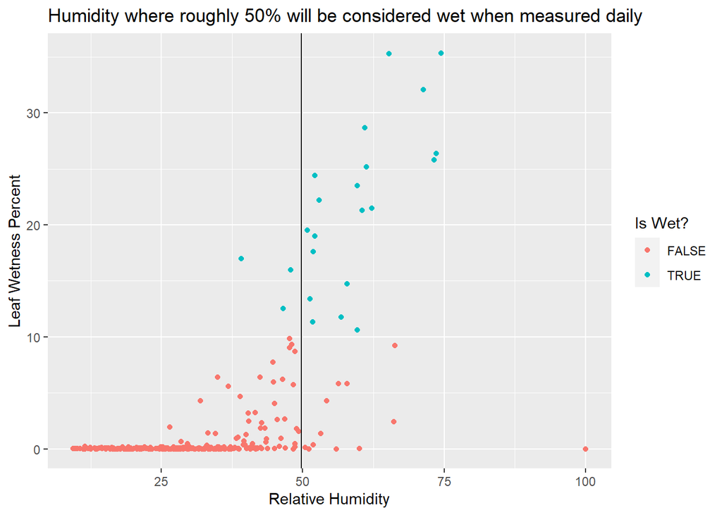

```r
ggplot(harmoComb.df)+ # Create a visual aid to determine how to approach
  geom_point(mapping = aes(x = `Relative Humidity`,
                           y = `Leaf Wetness Percent`,
                           color = `Is Wet?`))+
  geom_vline(xintercept = avgHum2)+
  labs(title = 'Humidity where roughly 50% will be considered wet when measured daily')
```

> An implicit assumption in the daily assumption that causes misunderstanding is that weather conditions such as relative humidity is completely consistent for the entire day. The hourly analysis is better at catching fluctuations in humidity throughout the day, though it may still combine fluctuations over the minute or second. The hourly analysis does have an advantage in that it doesn’t require sensors to measure every minute for over a year while still measuring fluctuations over the day.

# Implications

Circling back to the beginning of the assignment. Given that leaf litter in this system is water limited and only decays (losses mass) when it is wet. Why is a precipitation record a poor predictor of mass loss from this system and what would you use instead?

> Precipitation is a poor indicator of mass loss for this system because it doesn’t acount for the majority of the time when mass loss would be expected, as it was only 18% of the hours where there would be mass loss expected by wetness. A better judge of when to expect mass loss due to decomposition is relative humidity about 64%. It is more consistently aligned with when the leaf was detected to be wet.